# Variable selection

Written by [L. Collado-Torres](http://www.biostat.jhsph.edu/%7Elcollado/#.UZZK3ivF2L0).

# Setup

Load the data and get it ready to be used in the later steps.

```r
## Pkgs used
require(cvTools)
require(randomForest)
require(foreach)
require(doSNOW)
## Select the number of cores. By default 4 but can be passed externally
## to this Rmd file.  Basically, defined cores before running knit2html()
if (!"cores" %in% ls()) cores <- 4
registerDoSNOW(makeCluster(cores, type = "SOCK"))
getDoParWorkers()
```

```
## [1] 4
```

```r
## Load and process the data
library(lcollado754)
pre <- preprocess()
```

```
## Loan.Length, Loan.Purpose, Debt.To.Income.Ratio, State, Home.Ownership,
## Monthly.Income, FICO.Range, Open.CREDIT.Lines, Revolving.CREDIT.Balance,
## Employment.Length
```

```r
fdata <- postprocess(pre)
```

```
## Removing the earliest credit line information for 4 observations.
```

```r
## Drop rows with missing information
dim(fdata)
```

```
## [1] 2500   17
```

```r
fdata <- fdata[complete.cases(fdata), ]
dim(fdata)
```

```
## [1] 2348   17
```

```r
## Quick exploration
summary(fdata)
```

```
##  Amount.Requested Amount.Funded.By.Investors Interest.Rate
##  Min.   : 1000    Min.   :    0              Min.   : 5.42
##  1st Qu.: 6000    1st Qu.: 6000              1st Qu.:10.14
##  Median :10000    Median :10000              Median :13.11
##  Mean   :12406    Mean   :11979              Mean   :12.99
##  3rd Qu.:16800    3rd Qu.:16000              3rd Qu.:15.80
##  Max.   :35000    Max.   :35000              Max.   :24.89
##
##   Loan.Length   Debt.To.Income.Ratio Open.CREDIT.Lines
##  Min.   :36.0   Min.   : 0.00        Min.   : 2.0
##  1st Qu.:36.0   1st Qu.: 9.71        1st Qu.: 7.0
##  Median :36.0   Median :15.20        Median : 9.0
##  Mean   :41.3   Mean   :15.25        Mean   :10.1
##  3rd Qu.:36.0   3rd Qu.:20.50        3rd Qu.:13.0
##  Max.   :60.0   Max.   :34.91        Max.   :38.0
##
##  Inquiries.in.the.Last.6.Months  Issued.Date         Earliest.CREDIT.Line
##  Min.   :0.000                  Min.   :2007-07-05   Min.   :1969-05-20
##  1st Qu.:0.000                  1st Qu.:2011-03-31   1st Qu.:1994-09-02
##  Median :0.000                  Median :2012-03-07   Median :1998-12-26
##  Mean   :0.906                  Mean   :2011-10-22   Mean   :1997-10-19
##  3rd Qu.:1.000                  3rd Qu.:2012-09-17   3rd Qu.:2002-01-14
##  Max.   :9.000                  Max.   :2013-01-18   Max.   :2009-03-28
##
##  Total.CREDIT.Lines  State.Region    FICO.num   Monthly.Income.Log
##  Min.   : 3.0       09     :493   Min.   :642   Min.   : 6.38
##  1st Qu.:15.0       04     :397   1st Qu.:682   1st Qu.: 8.16
##  Median :22.0       02     :328   Median :702   Median : 8.52
##  Mean   :23.1       05     :265   Mean   :708   Mean   : 8.51
##  3rd Qu.:30.0       03     :262   3rd Qu.:732   3rd Qu.: 8.84
##  Max.   :63.0       06     :233   Max.   :832   Max.   :11.54
##                     (Other):370
##            Loan.Purpose.Mod Home.Ownership.Mod Employment.Length.Mod
##  credit_card       : 410    MORTGAGE:1078      10+ years:628
##  debt_consolidation:1229    OWN     : 183      < 1 year :242
##  other             : 709    RENT    :1087      2 years  :240
##                                                3 years  :230
##                                                5 years  :193
##                                                4 years  :187
##                                                (Other)  :628
##  Revolving.CREDIT.Balance.log
##  Min.   : 0.00
##  1st Qu.: 8.62
##  Median : 9.30
##  Mean   : 9.02
##  3rd Qu.: 9.85
##  Max.   :12.51
##
```

```r
## Separate into training and evaluation data sets
set.seed(20130517)
set.idx <- sample(c(TRUE, FALSE), nrow(fdata), replace = TRUE, prob = c(0.7,
    0.3))

## data will be the training data, edata will be the data set for
## evaluating
data <- fdata[set.idx, ]
edata <- fdata[!set.idx, ]

## Check that the proportion of obs reserved for evaluating the methods is
## around 30%
nrow(edata)/(nrow(edata) + nrow(data))
```

```
## [1] 0.3071
```

# Linear model

Below I fit a linear model, which technically is not correct because the interest rate has a domain of \([0, 100]\). But in the EDA steps it looked fairly bell-shaped and thus the linear model might be good enough. In addition, other variables had bell-shaped distributions.

When exploring the single term deletions, the FICO score is by far the one that affects the model the most.

Furthermore, we have evidence that the variable selected model performs better than the minimal model of just using the FICO score to determine the interest rate. However the full model is not significantly different from the variable selected model.

Finally, the diagnostic plots for the variable selected model look decent enough. Although there are a few observations that have much higher leverage. In more detail, some of these cases have very high revolving credit balance. It is hard to tell whether other factors are outliers as from a quick exploration most of the values seem to be within the first and third quartiles.

```r
flm <- lm(Interest.Rate ~ ., data = data)
summary(flm)
```

```
##
## Call:
## lm(formula = Interest.Rate ~ ., data = data)
##
## Residuals:
##    Min     1Q Median     3Q    Max
## -9.734 -1.284 -0.132  1.168  9.471
##
## Coefficients:
##                                     Estimate Std. Error t value Pr(>|t|)
## (Intercept)                         6.95e+01   2.86e+00   24.26  < 2e-16
## Amount.Requested                    5.17e-05   2.92e-05    1.77  0.07707
## Amount.Funded.By.Investors          1.25e-04   3.00e-05    4.17  3.2e-05
## Loan.Length                         1.32e-01   5.45e-03   24.16  < 2e-16
## Debt.To.Income.Ratio               -9.77e-03   7.99e-03   -1.22  0.22111
## Open.CREDIT.Lines                  -4.14e-03   1.56e-02   -0.27  0.79000
## Inquiries.in.the.Last.6.Months      3.43e-01   4.20e-02    8.17  6.0e-16
## Issued.Date                         2.47e-04   1.49e-04    1.65  0.09827
## Earliest.CREDIT.Line               -4.72e-05   2.38e-05   -1.98  0.04732
## Total.CREDIT.Lines                 -9.08e-04   6.76e-03   -0.13  0.89318
## State.Region02                     -1.23e-01   2.35e-01   -0.52  0.60078
## State.Region03                     -1.38e-01   2.47e-01   -0.56  0.57839
## State.Region04                      4.73e-02   2.30e-01    0.21  0.83719
## State.Region05                     -1.82e-01   2.47e-01   -0.74  0.46065
## State.Region06                      3.44e-01   2.52e-01    1.37  0.17200
## State.Region07                      2.83e-01   3.91e-01    0.72  0.46863
## State.Region08                     -1.45e-01   3.36e-01   -0.43  0.66583
## State.Region09                     -2.78e-02   2.24e-01   -0.12  0.90132
## State.Region10                      2.44e-01   3.19e-01    0.76  0.44498
## FICO.num                           -8.91e-02   1.54e-03  -57.79  < 2e-16
## Monthly.Income.Log                 -3.75e-01   1.26e-01   -2.97  0.00301
## Loan.Purpose.Moddebt_consolidation  1.97e-01   1.37e-01    1.44  0.15128
## Loan.Purpose.Modother               5.78e-01   1.57e-01    3.68  0.00024
## Home.Ownership.ModOWN               5.51e-01   1.91e-01    2.88  0.00407
## Home.Ownership.ModRENT              2.61e-01   1.17e-01    2.23  0.02582
## Employment.Length.Mod.L             1.91e-01   1.93e-01    0.99  0.32234
## Employment.Length.Mod.Q            -1.45e-01   1.63e-01   -0.89  0.37334
## Employment.Length.Mod.C            -1.31e-02   1.69e-01   -0.08  0.93815
## Employment.Length.Mod^4             1.74e-01   1.91e-01    0.91  0.36046
## Employment.Length.Mod^5            -1.07e-01   2.07e-01   -0.52  0.60617
```

[output cut: 34 more lines]

```
## Employment.Length.Mod.C
## Employment.Length.Mod^4
## Employment.Length.Mod^5
## Employment.Length.Mod^6
## Employment.Length.Mod^7
## Employment.Length.Mod^8
## Employment.Length.Mod^9
## Employment.Length.Mod^10
## Revolving.CREDIT.Balance.log       ***
## ---
## Signif. codes:  0 '***' 0.001 '**' 0.01 '*' 0.05 '.' 0.1 ' ' 1
##
## Residual standard error: 1.97 on 1591 degrees of freedom
## Multiple R-squared:  0.777,  Adjusted R-squared:  0.773
## F-statistic:  159 on 35 and 1591 DF,  p-value: <2e-16
```

```r
## Simple drop results
drop1(flm)
```

```
## Single term deletions
##
## Model:
## Interest.Rate ~ Amount.Requested + Amount.Funded.By.Investors +
##     Loan.Length + Debt.To.Income.Ratio + Open.CREDIT.Lines +
##     Inquiries.in.the.Last.6.Months + Issued.Date + Earliest.CREDIT.Line +
##     Total.CREDIT.Lines + State.Region + FICO.num + Monthly.Income.Log +
##     Loan.Purpose.Mod + Home.Ownership.Mod + Employment.Length.Mod +
##     Revolving.CREDIT.Balance.log
##                                Df Sum of Sq   RSS  AIC
## <none>                                       6184 2244
## Amount.Requested                1        12  6196 2246
## Amount.Funded.By.Investors      1        68  6251 2260
## Loan.Length                     1      2270  8453 2751
## Debt.To.Income.Ratio            1         6  6190 2244
## Open.CREDIT.Lines               1         0  6184 2242
## Inquiries.in.the.Last.6.Months  1       260  6443 2309
## Issued.Date                     1        11  6194 2245
## Earliest.CREDIT.Line            1        15  6199 2246
## Total.CREDIT.Lines              1         0  6184 2242
## State.Region                    9        39  6223 2237
## FICO.num                        1     12983 19166 4083
## Monthly.Income.Log              1        34  6218 2251
## Loan.Purpose.Mod                2        60  6244 2256
## Home.Ownership.Mod              2        39  6223 2251
## Employment.Length.Mod          10        22  6206 2230
## Revolving.CREDIT.Balance.log    1        92  6276 2266
```

```r
## Quick step-wise variable selection
flm.aic <- step(flm, trace = 0)
summary(flm.aic)
```

```
##
## Call:
## lm(formula = Interest.Rate ~ Amount.Requested + Amount.Funded.By.Investors +
##     Loan.Length + Debt.To.Income.Ratio + Inquiries.in.the.Last.6.Months +
##     Issued.Date + Earliest.CREDIT.Line + FICO.num + Monthly.Income.Log +
##     Loan.Purpose.Mod + Home.Ownership.Mod + Revolving.CREDIT.Balance.log,
##     data = data)
##
## Residuals:
##    Min     1Q Median     3Q    Max
## -9.815 -1.292 -0.128  1.192  9.680
##
## Coefficients:
##                                     Estimate Std. Error t value Pr(>|t|)
## (Intercept)                         6.95e+01   2.80e+00   24.84  < 2e-16
## Amount.Requested                    5.20e-05   2.90e-05    1.79  0.07323
## Amount.Funded.By.Investors          1.25e-04   2.98e-05    4.21  2.7e-05
## Loan.Length                         1.32e-01   5.39e-03   24.44  < 2e-16
## Debt.To.Income.Ratio               -1.05e-02   7.32e-03   -1.44  0.15000
## Inquiries.in.the.Last.6.Months      3.38e-01   4.11e-02    8.23  3.9e-16
## Issued.Date                         2.76e-04   1.46e-04    1.89  0.05882
## Earliest.CREDIT.Line               -5.11e-05   2.21e-05   -2.31  0.02106
## FICO.num                           -8.93e-02   1.53e-03  -58.52  < 2e-16
## Monthly.Income.Log                 -4.01e-01   1.18e-01   -3.41  0.00068
## Loan.Purpose.Moddebt_consolidation  1.98e-01   1.36e-01    1.45  0.14694
## Loan.Purpose.Modother               5.62e-01   1.55e-01    3.62  0.00031
## Home.Ownership.ModOWN               5.14e-01   1.88e-01    2.73  0.00634
## Home.Ownership.ModRENT              2.11e-01   1.10e-01    1.92  0.05550
## Revolving.CREDIT.Balance.log       -1.78e-01   3.56e-02   -4.99  6.7e-07
##
## (Intercept)                        ***
## Amount.Requested                   .
## Amount.Funded.By.Investors         ***
## Loan.Length                        ***
## Debt.To.Income.Ratio
## Inquiries.in.the.Last.6.Months     ***
## Issued.Date                        .
## Earliest.CREDIT.Line               *
## FICO.num                           ***
## Monthly.Income.Log                 ***
## Loan.Purpose.Moddebt_consolidation
## Loan.Purpose.Modother              ***
## Home.Ownership.ModOWN              **
## Home.Ownership.ModRENT             .
## Revolving.CREDIT.Balance.log       ***
## ---
## Signif. codes:  0 '***' 0.001 '**' 0.01 '*' 0.05 '.' 0.1 ' ' 1
##
## Residual standard error: 1.97 on 1612 degrees of freedom
## Multiple R-squared:  0.775,  Adjusted R-squared:  0.773
## F-statistic:  397 on 14 and 1612 DF,  p-value: <2e-16
```

```r
## Minimal model
small <- lm(Interest.Rate ~ FICO.num, data = data)
summary(small)
```

```
##
## Call:
## lm(formula = Interest.Rate ~ FICO.num, data = data)
##
## Residuals:
##    Min     1Q Median     3Q    Max
## -8.001 -2.108 -0.476  1.767  9.035
##
## Coefficients:
##             Estimate Std. Error t value Pr(>|t|)
## (Intercept) 71.96701    1.46603    49.1   <2e-16 ***
## FICO.num    -0.08316    0.00207   -40.2   <2e-16 ***
## ---
## Signif. codes:  0 '***' 0.001 '**' 0.01 '*' 0.05 '.' 0.1 ' ' 1
##
## Residual standard error: 2.93 on 1625 degrees of freedom
## Multiple R-squared:  0.499,  Adjusted R-squared:  0.499
## F-statistic: 1.62e+03 on 1 and 1625 DF,  p-value: <2e-16
```

```r
## Is the model an improvement over just using the FICO score?
anova(small, flm.aic, flm)
```

```
## Analysis of Variance Table
##
## Model 1: Interest.Rate ~ FICO.num
## Model 2: Interest.Rate ~ Amount.Requested + Amount.Funded.By.Investors +
##     Loan.Length + Debt.To.Income.Ratio + Inquiries.in.the.Last.6.Months +
##     Issued.Date + Earliest.CREDIT.Line + FICO.num + Monthly.Income.Log +
##     Loan.Purpose.Mod + Home.Ownership.Mod + Revolving.CREDIT.Balance.log
## Model 3: Interest.Rate ~ Amount.Requested + Amount.Funded.By.Investors +
##     Loan.Length + Debt.To.Income.Ratio + Open.CREDIT.Lines +
##     Inquiries.in.the.Last.6.Months + Issued.Date + Earliest.CREDIT.Line +
##     Total.CREDIT.Lines + State.Region + FICO.num + Monthly.Income.Log +
##     Loan.Purpose.Mod + Home.Ownership.Mod + Employment.Length.Mod +
##     Revolving.CREDIT.Balance.log
##   Res.Df   RSS Df Sum of Sq      F Pr(>F)
## 1   1625 13921
## 2   1612  6243 13      7678 151.95 <2e-16 ***
## 3   1591  6184 21        60   0.73    0.8
## ---
## Signif. codes:  0 '***' 0.001 '**' 0.01 '*' 0.05 '.' 0.1 ' ' 1
```

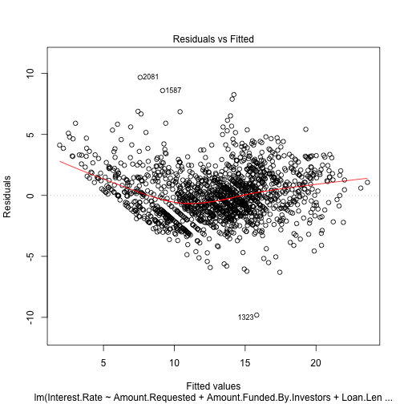

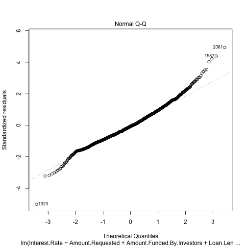

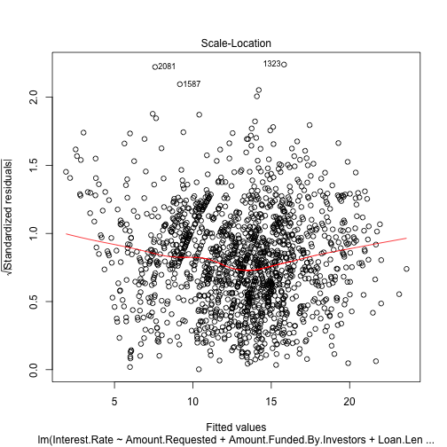

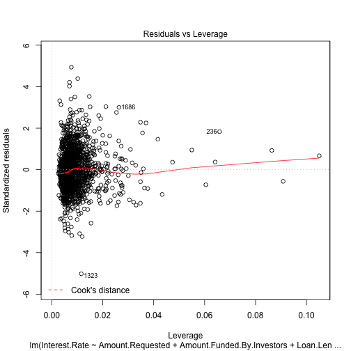

```r
## Diagnostic plots
plot(flm.aic)
```

```r
## A deeper look at the observations with high leverage
data[hatvalues(flm.aic) > 0.03, ]
```

```
##      Amount.Requested Amount.Funded.By.Investors Interest.Rate Loan.Length
## 43               5500                     5500.0         19.13          36
## 76               6725                      825.0         13.12          36
## 133             24625                      917.3         14.07          36
## 236             20000                     2050.0         12.84          36
## 523             14700                     1973.8         12.29          36
## 571              3000                     3000.0         22.11          60
## 701             21000                     6165.3         11.09          36
## 834             24000                     7100.0         11.12          60
## 1064             2800                     2800.0         14.17          36
## 1195             3000                     3000.0         19.99          60
## 1242            35000                    14869.5         15.65          60
## 1305            10000                      525.0         14.70          36
## 1342             8000                     7950.0          5.79          36
## 1413            20000                     6350.0         16.71          36
```

[output cut: 120 more lines]

# Cross-validate the linear model

```r
## CV setup
seed <- 201305017
K <- 10
R <- 5
set.seed(seed)
folds <- cvFolds(nrow(data), K = K, R = R)

## Run it
cv.flmaic <- cvFit(flm.aic, y = data$Interest.Rate, data = data, folds = folds,
    costArgs = list(includeSE = TRUE))

## Estimate of the prediction error using rmspe: robust mean squared
## prediction error
cv.flmaic
```

```
## 10-fold CV results:
##    CV
## 1.979
```

```r
cv.flmaic$se
```

```
##       CV
## 0.001352
```

# Random forest

```r
# rf <- foreach(ntree = rep(100, cores), .combine = combine, .packages =
# 'randomForest') %dopar% randomForest(x = data, y = data$Interest.Rate,
# data = data, xtest = edata, ytest = edata$Interest.Rate, importance =
# TRUE, keep.forest = TRUE, ntree = ntree)
rf <- foreach(ntree = rep(200, cores), .combine = combine, .packages = "randomForest") %dopar%
    randomForest(Interest.Rate ~ ., data = data, importance = TRUE, keep.forest = TRUE,
        ntree = ntree, xtest = edata[, -which(colnames(edata) == "Interest.Rate")],
        ytest = edata$Interest.Rate)

## Importance
rf$importance
```

```
##                                 %IncMSE IncNodePurity
## Amount.Requested                1.45010        1598.8
## Amount.Funded.By.Investors      1.78681        2009.6
## Loan.Length                     4.00779        3269.1
## Debt.To.Income.Ratio            0.11818         652.4
## Open.CREDIT.Lines               0.26711         656.0
## Inquiries.in.the.Last.6.Months  0.49359         606.1
## Issued.Date                     0.81815        1450.2
## Earliest.CREDIT.Line            0.08942         602.3
## Total.CREDIT.Lines              0.13913         585.5
## State.Region                    0.01207         830.7
## FICO.num                       17.52130       13174.8
## Monthly.Income.Log              0.08655         515.5
## Loan.Purpose.Mod                0.05170         165.8
## Home.Ownership.Mod              0.04808         171.1
## Employment.Length.Mod           0.02338         251.7
## Revolving.CREDIT.Balance.log    0.16710         720.2
```

```r
rf$importanceSD
```

```
##               Amount.Requested     Amount.Funded.By.Investors
##                        0.07903                        0.09320
##                    Loan.Length           Debt.To.Income.Ratio
##                        0.08334                        0.02677
##              Open.CREDIT.Lines Inquiries.in.the.Last.6.Months
##                        0.02342                        0.03051
##                    Issued.Date           Earliest.CREDIT.Line
##                        0.04191                        0.02505
##             Total.CREDIT.Lines                   State.Region
##                        0.02438                        0.02601
##                       FICO.num             Monthly.Income.Log
##                        0.17134                        0.02323
##               Loan.Purpose.Mod             Home.Ownership.Mod
##                        0.01326                        0.01395
##          Employment.Length.Mod   Revolving.CREDIT.Balance.log
##                        0.01512                        0.03201
```

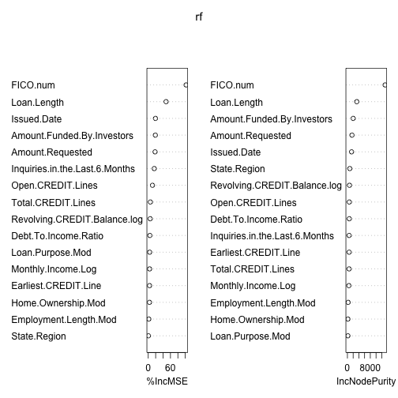

```r
## Importance plot
varImpPlot(rf)
```

```r
## variables used
rf.used <- data.frame(Var = rownames(rf$importance), Used = varUsed(rf))
rf.used
```

```
##                               Var  Used
## 1                Amount.Requested 29607
## 2      Amount.Funded.By.Investors 31931
## 3                     Loan.Length  5278
## 4            Debt.To.Income.Ratio 31892
## 5               Open.CREDIT.Lines 27160
## 6  Inquiries.in.the.Last.6.Months 13645
## 7                     Issued.Date 42005
## 8            Earliest.CREDIT.Line 31525
## 9              Total.CREDIT.Lines 29351
## 10                   State.Region 39225
## 11                       FICO.num 40187
## 12             Monthly.Income.Log 30097
## 13               Loan.Purpose.Mod 11024
## 14             Home.Ownership.Mod 10085
## 15          Employment.Length.Mod 19908
## 16   Revolving.CREDIT.Balance.log 32166
```

```r
## Prediction error
e.rf <- rmspe(edata$Interest.Rate, predict(rf, edata), includeSE = TRUE)
e.rf
```

```
## $rmspe
## [1] 1.595
##
## $se
## [1] 0.05685
```

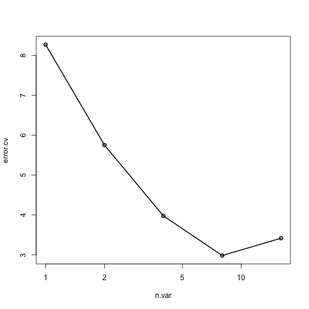

```r
## Cross validate the rf and see how many variables should be used: result
## is 8
rf.cv <- rfcv(trainx = data[, -which(colnames(data) == "Interest.Rate")], trainy = data$Interest.Rate,
    keep.forest = TRUE, ntree = 100)
with(rf.cv, plot(n.var, error.cv, log = "x", type = "o", lwd = 2))
```

```r
## Select the top 8 variables
varsToUse <- rownames(rf$importance)[order(rf$importance[, 1], decreasing = TRUE)[1:8]]
varsToUse
```

```
## [1] "FICO.num"                       "Loan.Length"
## [3] "Amount.Funded.By.Investors"     "Amount.Requested"
## [5] "Issued.Date"                    "Inquiries.in.the.Last.6.Months"
## [7] "Open.CREDIT.Lines"              "Revolving.CREDIT.Balance.log"
```

```r
## Looks similar to the ones selected with lm and step
flm.aic$call
```

```
## lm(formula = Interest.Rate ~ Amount.Requested + Amount.Funded.By.Investors +
##     Loan.Length + Debt.To.Income.Ratio + Inquiries.in.the.Last.6.Months +
##     Issued.Date + Earliest.CREDIT.Line + FICO.num + Monthly.Income.Log +
##     Loan.Purpose.Mod + Home.Ownership.Mod + Revolving.CREDIT.Balance.log,
##     data = data)
```

```r
## Random forest with
paste(varsToUse, collapse = " + ")  # To get the vars
```

```
## [1] "FICO.num + Loan.Length + Amount.Funded.By.Investors + Amount.Requested + Issued.Date + Inquiries.in.the.Last.6.Months + Open.CREDIT.Lines + Revolving.CREDIT.Balance.log"
```

```r
rf2 <- foreach(ntree = rep(100, cores), .combine = combine, .packages = "randomForest") %dopar%
    randomForest(Interest.Rate ~ FICO.num + Loan.Length + Amount.Funded.By.Investors +
        Amount.Requested + Issued.Date + Inquiries.in.the.Last.6.Months + Open.CREDIT.Lines +
        Revolving.CREDIT.Balance.log, data = data, importance = TRUE, keep.forest = TRUE,
        ntree = ntree, xtest = edata[, which(colnames(edata) %in% varsToUse)],
        ytest = edata$Interest.Rate)

## Importance
rf2$importance
```

```
##                                %IncMSE IncNodePurity
## FICO.num                       17.4741       13066.7
## Loan.Length                     4.0675        3222.3
## Amount.Funded.By.Investors      2.3143        2428.5
## Amount.Requested                1.9103        2042.9
## Issued.Date                     1.0275        2156.9
## Inquiries.in.the.Last.6.Months  0.5708         870.5
## Open.CREDIT.Lines               0.4391        1281.7
## Revolving.CREDIT.Balance.log    0.2777        1420.4
```

```r
rf2$importanceSD
```

```
##                       FICO.num                    Loan.Length
##                        0.25971                        0.11932
##     Amount.Funded.By.Investors               Amount.Requested
##                        0.16701                        0.12059
##                    Issued.Date Inquiries.in.the.Last.6.Months
##                        0.06732                        0.05407
##              Open.CREDIT.Lines   Revolving.CREDIT.Balance.log
##                        0.04456                        0.05956
```

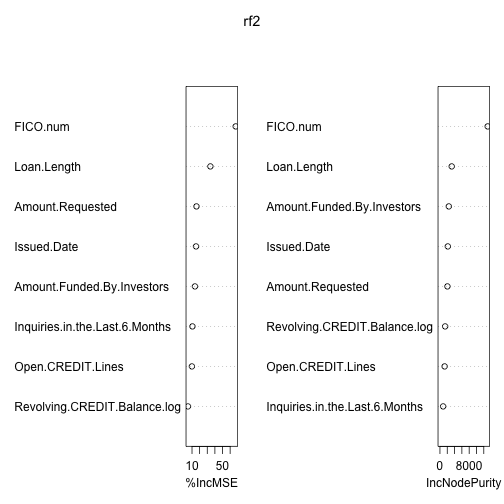

```r
## Importance plot
varImpPlot(rf2)
```

```r
## variables used
rf2.used <- data.frame(Var = rownames(rf$importance), Used = varUsed(rf))
rf2.used
```

```
##                               Var  Used
## 1                Amount.Requested 29607
## 2      Amount.Funded.By.Investors 31931
## 3                     Loan.Length  5278
## 4            Debt.To.Income.Ratio 31892
## 5               Open.CREDIT.Lines 27160
## 6  Inquiries.in.the.Last.6.Months 13645
## 7                     Issued.Date 42005
## 8            Earliest.CREDIT.Line 31525
## 9              Total.CREDIT.Lines 29351
## 10                   State.Region 39225
## 11                       FICO.num 40187
## 12             Monthly.Income.Log 30097
## 13               Loan.Purpose.Mod 11024
## 14             Home.Ownership.Mod 10085
## 15          Employment.Length.Mod 19908
## 16   Revolving.CREDIT.Balance.log 32166
```

```r
## Prediction error
e.rf2 <- rmspe(edata$Interest.Rate, predict(rf2, edata), includeSE = TRUE)
e.rf2
```

```
## $rmspe
## [1] 1.547
##
## $se
## [1] 0.05625
```

```r
## Slightly better than before
```

# Evaluate the methods

The last random forest model performs better than the linear model and the naive random forest. This model will be used in the successive steps.

```r
## Methods evaluated on the 30% of the data using robust mean squared
## prediction error (rmspe)
rmspe(edata$Interest.Rate, predict(flm.aic, edata), includeSE = TRUE)
```

```
## $rmspe
## [1] 1.976
##
## $se
## [1] 0.0614
```

```r
e.rf
```

```
## $rmspe
## [1] 1.595
##
## $se
## [1] 0.05685
```

```r
e.rf2
```

```
## $rmspe
## [1] 1.547
##
## $se
## [1] 0.05625
```

# Save the model to be used

```r
model <- rf2
save(model, file = "model.Rdata")
```

```r
print(proc.time())
```

```
##    user  system elapsed
##  34.752   1.782 242.097
```